# Konza_synoptic_ITS1_bioinformatics_pipeline

Charles T. Bond

2023-09-15

### Setup

It loads the package before it begins or else it gets the error again

```r
library(dada2)
packageVersion("dada2")
```

```
## [1] '1.26.0'
```

```r
library(ShortRead)
packageVersion("ShortRead")
```

```
## [1] '1.56.1'
```

```r
library(Biostrings)
packageVersion("Biostrings")
```

```
## [1] '2.66.0'
```

```r
library(phyloseq)
library(vegan)
library(ggplot2)
library(tidyr)
library(dplyr)
library(pheatmap)
library(GUniFrac)
#library(metagMisc)
#library(raster)
#library(pals)
#library(RColorBrewer)
#library(ragg)
library(ggpubr)
```

Going to drop some citations for key packages here: McMurdie PJ, Holmes S (2013). “phyloseq: An R package for reproducible interactive analysis and graphics of microbiome census data.” PLoS ONE, 8(4), e61217. http://dx.plos.org/10.1371/journal.pone.0061217.

Now the our libraries are loaded, ## Set Theme Setting themes determines how our figures will look, readability and publishability. This can be modified later, but here is the starting point:

```r
#Set theme
theme_set(theme_bw() + theme(
              plot.title = element_blank(),
              axis.text.x = element_text(size=10, color="black"),
              axis.text.y = element_text(size=10, color="black"),
              axis.title.x = element_text(size=10),
              axis.title.y = element_text(size=10),
              legend.text = element_text(size=10),
              legend.title = element_text(size=10),
              legend.position = "bottom",
              legend.key=element_blank(),
              legend.key.size = unit(0.5, "cm"),
              legend.spacing.x = unit(0.1, "cm"),
              legend.spacing.y = unit(0.1, "cm"),
              panel.background = element_blank(),
              panel.border = element_rect(colour = "black", fill=NA, size=1),
              plot.background = element_blank()))
```

Now that our workspace is set up, time for the actual pipeline.

## DADA2 Amplicon Sequence Data Pipeline:

Defining file path so R can find our raw fastq files. Make sure forward reads (R1) and reverse reads (R2) are in the same folder. This will need to be changed for different analyses.

```r
path <- "/Users/kuehnlab/Publishing/AIMS_KonzaSyn_ITS/fastq"
list.files(path)
```

```
##   [1] "01m01-B_S34_L001_R1_001.fastq"  "01m01-B_S34_L001_R2_001.fastq"
##   [3] "01m01-L_S4_L001_R1_001.fastq"   "01m01-L_S4_L001_R2_001.fastq"
##   [5] "01m01-S_S148_L001_R1_001.fastq" "01m01-S_S148_L001_R2_001.fastq"
##   [7] "01m02-B_S46_L001_R1_001.fastq"  "01m02-B_S46_L001_R2_001.fastq"
##   [9] "01m02-L_S16_L001_R1_001.fastq"  "01m02-L_S16_L001_R2_001.fastq"
##  [11] "01m02-S_S160_L001_R1_001.fastq" "01m02-S_S160_L001_R2_001.fastq"
##  [13] "01m03-B_S58_L001_R1_001.fastq"  "01m03-B_S58_L001_R2_001.fastq"
##  [15] "01m03-L_S28_L001_R1_001.fastq"  "01m03-L_S28_L001_R2_001.fastq"
##  [17] "01m03-S_S172_L001_R1_001.fastq" "01m03-S_S172_L001_R2_001.fastq"
##  [19] "01m03-W_S142_L001_R1_001.fastq" "01m03-W_S142_L001_R2_001.fastq"
##  [21] "01m04-B_S70_L001_R1_001.fastq"  "01m04-B_S70_L001_R2_001.fastq"
##  [23] "01m04-L_S40_L001_R1_001.fastq"  "01m04-L_S40_L001_R2_001.fastq"
##  [25] "01m04-S_S184_L001_R1_001.fastq" "01m04-S_S184_L001_R2_001.fastq"
##  [27] "01m05-B_S82_L001_R1_001.fastq"  "01m05-B_S82_L001_R2_001.fastq"
##  [29] "01m05-L_S52_L001_R1_001.fastq"  "01m05-L_S52_L001_R2_001.fastq"
```

[output cut: 135 more lines]

Now that forward and reverse reads are loaded, we’ll sort and name the samples.

```r
#Forward and reverse fastq filenames
fnFs <- sort(list.files(path, pattern="_R1_001.fastq", full.names = TRUE))
fnRs <- sort(list.files(path, pattern="_R2_001.fastq", full.names = TRUE))

library(stringr)
#Extract sample names
sample.names <- sapply(strsplit(basename(fnFs), "_L001_R1_001"), `[`, 1)
sample.names <- sapply(strsplit(basename(fnFs), "_S"), `[`, 1)
sample.names <- sapply(str_replace(sample.names, "-", "_"),`[`, 1)
sample.names <- sapply(paste0('kz.s_', sample.names),`[`, 1)
sample.names
```

```
##   kz.s_01m01_B   kz.s_01m01_L   kz.s_01m01_S   kz.s_01m02_B   kz.s_01m02_L
## "kz.s_01m01_B" "kz.s_01m01_L" "kz.s_01m01_S" "kz.s_01m02_B" "kz.s_01m02_L"
##   kz.s_01m02_S   kz.s_01m03_B   kz.s_01m03_L   kz.s_01m03_S   kz.s_01m03_W
## "kz.s_01m02_S" "kz.s_01m03_B" "kz.s_01m03_L" "kz.s_01m03_S" "kz.s_01m03_W"
##   kz.s_01m04_B   kz.s_01m04_L   kz.s_01m04_S   kz.s_01m05_B   kz.s_01m05_L
## "kz.s_01m04_B" "kz.s_01m04_L" "kz.s_01m04_S" "kz.s_01m05_B" "kz.s_01m05_L"
##   kz.s_01m05_S   kz.s_01m06_B   kz.s_01m06_L   kz.s_01m06_S   kz.s_02m01_B
## "kz.s_01m05_S" "kz.s_01m06_B" "kz.s_01m06_L" "kz.s_01m06_S" "kz.s_02m01_B"
##   kz.s_02m01_L   kz.s_02m01_S   kz.s_02m02_B   kz.s_02m02_L   kz.s_02m02_S
## "kz.s_02m01_L" "kz.s_02m01_S" "kz.s_02m02_B" "kz.s_02m02_L" "kz.s_02m02_S"
##   kz.s_02m03_B   kz.s_02m03_L   kz.s_02m03_S   kz.s_02m04_L   kz.s_02m04_S
## "kz.s_02m03_B" "kz.s_02m03_L" "kz.s_02m03_S" "kz.s_02m04_L" "kz.s_02m04_S"
##   kz.s_02m05_B   kz.s_02m05_L   kz.s_02m06_B   kz.s_02m06_L   kz.s_02m06_S
## "kz.s_02m05_B" "kz.s_02m05_L" "kz.s_02m06_B" "kz.s_02m06_L" "kz.s_02m06_S"
##   kz.s_02m07_B   kz.s_02m07_L   kz.s_02m07_S   kz.s_02m08_B   kz.s_02m08_L
## "kz.s_02m07_B" "kz.s_02m07_L" "kz.s_02m07_S" "kz.s_02m08_B" "kz.s_02m08_L"
##   kz.s_02m08_S   kz.s_02m09_B   kz.s_02m09_L   kz.s_02m09_S   kz.s_02m10_B
## "kz.s_02m08_S" "kz.s_02m09_B" "kz.s_02m09_L" "kz.s_02m09_S" "kz.s_02m10_B"
##   kz.s_02m10_L   kz.s_02m10_S   kz.s_02m11_B   kz.s_02m11_S   kz.s_02m11_W
## "kz.s_02m10_L" "kz.s_02m10_S" "kz.s_02m11_B" "kz.s_02m11_S" "kz.s_02m11_W"
##   kz.s_04m01_B   kz.s_04m01_L   kz.s_04m01_S   kz.s_04m02_B   kz.s_04m02_L
## "kz.s_04m01_B" "kz.s_04m01_L" "kz.s_04m01_S" "kz.s_04m02_B" "kz.s_04m02_L"
##   kz.s_04m02_S   kz.s_04m03_B   kz.s_04m03_L   kz.s_04m03_S   kz.s_04m04_B
## "kz.s_04m02_S" "kz.s_04m03_B" "kz.s_04m03_L" "kz.s_04m03_S" "kz.s_04m04_B"
##   kz.s_04m04_L   kz.s_04m04_S   kz.s_04m05_B   kz.s_04m05_L   kz.s_04m05_S
## "kz.s_04m04_L" "kz.s_04m04_S" "kz.s_04m05_B" "kz.s_04m05_L" "kz.s_04m05_S"
##   kz.s_04m06_B   kz.s_04m06_L   kz.s_04m06_S   kz.s_04m07_L   kz.s_04m07_S
## "kz.s_04m06_B" "kz.s_04m06_L" "kz.s_04m06_S" "kz.s_04m07_L" "kz.s_04m07_S"
##   kz.s_04m08_B   kz.s_04m08_L   kz.s_04m08_S   kz.s_04m09_B   kz.s_04m09_L
## "kz.s_04m08_B" "kz.s_04m08_L" "kz.s_04m08_S" "kz.s_04m09_B" "kz.s_04m09_L"
##   kz.s_04m09_S   kz.s_04m10_B   kz.s_04m10_L   kz.s_04m10_S   kz.s_04m11_B
## "kz.s_04m09_S" "kz.s_04m10_B" "kz.s_04m10_L" "kz.s_04m10_S" "kz.s_04m11_B"
##   kz.s_04m11_L   kz.s_04m11_S   kz.s_04m11_W   kz.s_04m12_B   kz.s_04m12_L
## "kz.s_04m11_L" "kz.s_04m11_S" "kz.s_04m11_W" "kz.s_04m12_B" "kz.s_04m12_L"
##   kz.s_04m12_S   kz.s_04m13_B   kz.s_04m13_L   kz.s_04m13_S   kz.s_04t01_B
## "kz.s_04m12_S" "kz.s_04m13_B" "kz.s_04m13_L" "kz.s_04m13_S" "kz.s_04t01_B"
##   kz.s_04t01_L   kz.s_04t01_S   kz.s_04t02_B   kz.s_04t02_L   kz.s_04t02_S
## "kz.s_04t01_L" "kz.s_04t01_S" "kz.s_04t02_B" "kz.s_04t02_L" "kz.s_04t02_S"
##   kz.s_04w01_B   kz.s_04w01_L   kz.s_04w01_S   kz.s_04w02_B   kz.s_04w02_L
## "kz.s_04w01_B" "kz.s_04w01_L" "kz.s_04w01_S" "kz.s_04w02_B" "kz.s_04w02_L"
##   kz.s_04w02_S   kz.s_04w03_B   kz.s_04w03_L   kz.s_04w03_S   kz.s_04w04_L
## "kz.s_04w02_S" "kz.s_04w03_B" "kz.s_04w03_L" "kz.s_04w03_S" "kz.s_04w04_L"
##   kz.s_04w04_S   kz.s_20m01_L   kz.s_20m01_S   kz.s_20m02_B   kz.s_20m02_L
## "kz.s_04w04_S" "kz.s_20m01_L" "kz.s_20m01_S" "kz.s_20m02_B" "kz.s_20m02_L"
##   kz.s_20m02_S   kz.s_20m02_W   kz.s_20m03_B   kz.s_20m03_L   kz.s_20m03_S
## "kz.s_20m02_S" "kz.s_20m02_W" "kz.s_20m03_B" "kz.s_20m03_L" "kz.s_20m03_S"
##   kz.s_20m04_B   kz.s_20m04_L   kz.s_20m04_S   kz.s_20m04_W   kz.s_20m05_B
## "kz.s_20m04_B" "kz.s_20m04_L" "kz.s_20m04_S" "kz.s_20m04_W" "kz.s_20m05_B"
##   kz.s_20m05_L   kz.s_20m05_S   kz.s_sfm01_B   kz.s_sfm01_L   kz.s_sfm01_S
## "kz.s_20m05_L" "kz.s_20m05_S" "kz.s_sfm01_B" "kz.s_sfm01_L" "kz.s_sfm01_S"
##   kz.s_sfm02_B   kz.s_sfm02_L   kz.s_sfm02_S   kz.s_sfm03_B   kz.s_sfm03_L
## "kz.s_sfm02_B" "kz.s_sfm02_L" "kz.s_sfm02_S" "kz.s_sfm03_B" "kz.s_sfm03_L"
##   kz.s_sfm03_S   kz.s_sfm04_B   kz.s_sfm04_L   kz.s_sfm04_S   kz.s_sfm05_B
## "kz.s_sfm03_S" "kz.s_sfm04_B" "kz.s_sfm04_L" "kz.s_sfm04_S" "kz.s_sfm05_B"
##   kz.s_sfm05_L   kz.s_sfm05_S   kz.s_sfm06_B   kz.s_sfm06_L   kz.s_sfm06_S
## "kz.s_sfm05_L" "kz.s_sfm05_S" "kz.s_sfm06_B" "kz.s_sfm06_L" "kz.s_sfm06_S"
##   kz.s_sfm07_B   kz.s_sfm07_L   kz.s_sfm07_S   kz.s_Sft01_B   kz.s_Sft01_L
## "kz.s_sfm07_B" "kz.s_sfm07_L" "kz.s_sfm07_S" "kz.s_Sft01_B" "kz.s_Sft01_L"
##   kz.s_Sft01_S   kz.s_Sft02_B   kz.s_Sft02_L   kz.s_Sft02_S
## "kz.s_Sft01_S" "kz.s_Sft02_B" "kz.s_Sft02_L" "kz.s_Sft02_S"
```

### Identify primers

I am adding this step to ensure that primers have been properly removed

```r
#BITS
FWD <- "ACCTGCGGARGGATCA"

## B58S3
REV <- "GAGATCCRTTGYTRAAAGTT"

allOrients <- function(primer) {
    # Create all orientations of the input sequence
    require(Biostrings)
    dna <- DNAString(primer)  # The Biostrings works w/ DNAString objects rather than character vectors
    orients <- c(Forward = dna, Complement = complement(dna), Reverse = reverse(dna),
        RevComp = reverseComplement(dna))
    return(sapply(orients, toString))  # Convert back to character vector
}
FWD.orients <- allOrients(FWD)
REV.orients <- allOrients(REV)
FWD.orients
```

```
##            Forward         Complement            Reverse            RevComp
## "ACCTGCGGARGGATCA" "TGGACGCCTYCCTAGT" "ACTAGGRAGGCGTCCA" "TGATCCYTCCGCAGGT"
```

```r
###The presence of ambiguous bases (Ns) in the sequencing reads makes accurate mapping of short primer sequences difficult. Next we are going to “pre-filter” the sequences just to remove those with Ns, but perform no other filtering.
fnFs.filtN <- file.path(path, "filtN", basename(fnFs))
# Put N-filterd files in filtN/ subdirectory
fnRs.filtN <- file.path(path, "filtN", basename(fnRs))
filterAndTrim(fnFs, fnFs.filtN, fnRs, fnRs.filtN, maxN = 0, multithread = TRUE)
```

```r
#We are now ready to count the number of times the primers appear in the forward and reverse read, while considering all possible primer orientations. Identifying and counting the primers on one set of paired end FASTQ files is sufficient, assuming all the files were created using the same library preparation, so we’ll just process the first sample.

primerHits <- function(primer, fn) {
    # Counts number of reads in which the primer is found
    nhits <- vcountPattern(primer, sread(readFastq(fn)), fixed = FALSE)
    return(sum(nhits > 0))
}
rbind(FWD.ForwardReads = sapply(FWD.orients, primerHits, fn = fnFs.filtN[[1]]),
    FWD.ReverseReads = sapply(FWD.orients, primerHits, fn = fnRs.filtN[[1]]),
    REV.ForwardReads = sapply(REV.orients, primerHits, fn = fnFs.filtN[[1]]),
    REV.ReverseReads = sapply(REV.orients, primerHits, fn = fnRs.filtN[[1]]))
```

```
##                  Forward Complement Reverse RevComp
## FWD.ForwardReads       0          0       0       0
## FWD.ReverseReads       0          0       0    9753
## REV.ForwardReads       0          0       0   13874
## REV.ReverseReads       0          0       0       0
```

[output not shown]

```r
#cutadapt <- "/Users/kuehnlab/opt/anaconda3/envs/cutadaptenv/bin/cutadapt" # CHANGE ME to the cutadapt path on your machine
cutadapt <- "/Users/kuehnlab/miniconda3/envs/qiime2-2022.11/bin/cutadapt"

system2(cutadapt, args = "--version") # Run shell commands from R
```

NOTE: -m 45 == minimum length of 45, because my I’d like to go ahead and drop those itty bitty reads altogether.

```r
path.cut <- file.path(path, "cutadapt")
if(!dir.exists(path.cut)) dir.create(path.cut)
fnFs.cut <- file.path(path.cut, basename(fnFs))
fnRs.cut <- file.path(path.cut, basename(fnRs))

FWD.RC <- dada2:::rc(FWD)
REV.RC <- dada2:::rc(REV)
# Trim FWD and the reverse-complement of REV off of R1 (forward reads)
R1.flags <- paste("-g", FWD, "-a", REV.RC)
# Trim REV and the reverse-complement of FWD off of R2 (reverse reads)
R2.flags <- paste("-G", REV, "-A", FWD.RC)
# Run Cutadapt

### Note, Charlie initially added argument "-m 1" below to remove remnant reads of length zero. Now attempting with min length more stringent min length, something just below downstream minimum length, e.g. 45 is below downstream length of 50...

for(i in seq_along(fnFs)) {
  system2(cutadapt, args = c(R1.flags, R2.flags, "-m", 45, "-n", 2, # -n 2 required to remove FWD and REV from reads
                             "-o", fnFs.cut[i], "-p", fnRs.cut[i], # output files
                             fnFs.filtN[i], fnRs.filtN[i])) # input files
}
```

###Charlie note: The output gives a warning to check the adapter sequences: `WARNING:` `The adapter is preceded by 'A' extremely often.` `The provided adapter sequence could be incomplete at its 5' end.` `Ignore this warning when trimming primers.`

HOWEVER, we can `Ignore this warning` , because we’re `trimming primers.` Adapters are on the outside of the primers, so by trimming primers, we are without a doubt also trimming off adapters. So just ignore the warning, we’re good.

#Sanity check, did it work?

```r
rbind(FWD.ForwardReads = sapply(FWD.orients, primerHits, fn = fnFs.cut[[1]]),
    FWD.ReverseReads = sapply(FWD.orients, primerHits, fn = fnRs.cut[[1]]),
    REV.ForwardReads = sapply(REV.orients, primerHits, fn = fnFs.cut[[1]]),
    REV.ReverseReads = sapply(REV.orients, primerHits, fn = fnRs.cut[[1]]))
```

```
##                  Forward Complement Reverse RevComp
## FWD.ForwardReads       0          0       0       0
## FWD.ReverseReads       0          0       0       0
## REV.ForwardReads       0          0       0       0
## REV.ReverseReads       0          0       0       0
```

```r
# Forward and reverse fastq filenames have the format:
cutFs <- sort(list.files(path.cut, pattern = "_R1_001.fastq", full.names = TRUE))
cutRs <- sort(list.files(path.cut, pattern = "_R2_001.fastq", full.names = TRUE))

# Extract sample names, assuming filenames have format:
get.sample.name <- function(fname) strsplit(basename(fname), "_")[[1]][1]
sample.names <- unname(sapply(cutFs, get.sample.name))
head(sample.names)
```

```
## [1] "01m01-B" "01m01-L" "01m01-S" "01m02-B" "01m02-L" "01m02-S"
```

```r
library(stringr)
#Extract sample names
sample.names <- sapply(str_replace(sample.names, "-", "_"),`[`, 1)
#sample.names <- sapply(paste0('kz.s_', sample.names),`[`, 1)
sample.names
```

```
##   01m01_B   01m01_L   01m01_S   01m02_B   01m02_L   01m02_S   01m03_B   01m03_L
## "01m01_B" "01m01_L" "01m01_S" "01m02_B" "01m02_L" "01m02_S" "01m03_B" "01m03_L"
##   01m03_S   01m03_W   01m04_B   01m04_L   01m04_S   01m05_B   01m05_L   01m05_S
## "01m03_S" "01m03_W" "01m04_B" "01m04_L" "01m04_S" "01m05_B" "01m05_L" "01m05_S"
##   01m06_B   01m06_L   01m06_S   02m01_B   02m01_L   02m01_S   02m02_B   02m02_L
## "01m06_B" "01m06_L" "01m06_S" "02m01_B" "02m01_L" "02m01_S" "02m02_B" "02m02_L"
##   02m02_S   02m03_B   02m03_L   02m03_S   02m04_L   02m04_S   02m05_B   02m05_L
## "02m02_S" "02m03_B" "02m03_L" "02m03_S" "02m04_L" "02m04_S" "02m05_B" "02m05_L"
##   02m06_B   02m06_L   02m06_S   02m07_B   02m07_L   02m07_S   02m08_B   02m08_L
## "02m06_B" "02m06_L" "02m06_S" "02m07_B" "02m07_L" "02m07_S" "02m08_B" "02m08_L"
##   02m08_S   02m09_B   02m09_L   02m09_S   02m10_B   02m10_L   02m10_S   02m11_B
## "02m08_S" "02m09_B" "02m09_L" "02m09_S" "02m10_B" "02m10_L" "02m10_S" "02m11_B"
##   02m11_S   02m11_W   04m01_B   04m01_L   04m01_S   04m02_B   04m02_L   04m02_S
## "02m11_S" "02m11_W" "04m01_B" "04m01_L" "04m01_S" "04m02_B" "04m02_L" "04m02_S"
##   04m03_B   04m03_L   04m03_S   04m04_B   04m04_L   04m04_S   04m05_B   04m05_L
## "04m03_B" "04m03_L" "04m03_S" "04m04_B" "04m04_L" "04m04_S" "04m05_B" "04m05_L"
##   04m05_S   04m06_B   04m06_L   04m06_S   04m07_L   04m07_S   04m08_B   04m08_L
## "04m05_S" "04m06_B" "04m06_L" "04m06_S" "04m07_L" "04m07_S" "04m08_B" "04m08_L"
##   04m08_S   04m09_B   04m09_L   04m09_S   04m10_B   04m10_L   04m10_S   04m11_B
## "04m08_S" "04m09_B" "04m09_L" "04m09_S" "04m10_B" "04m10_L" "04m10_S" "04m11_B"
##   04m11_L   04m11_S   04m11_W   04m12_B   04m12_L   04m12_S   04m13_B   04m13_L
## "04m11_L" "04m11_S" "04m11_W" "04m12_B" "04m12_L" "04m12_S" "04m13_B" "04m13_L"
##   04m13_S   04t01_B   04t01_L   04t01_S   04t02_B   04t02_L   04t02_S   04w01_B
## "04m13_S" "04t01_B" "04t01_L" "04t01_S" "04t02_B" "04t02_L" "04t02_S" "04w01_B"
##   04w01_L   04w01_S   04w02_B   04w02_L   04w02_S   04w03_B   04w03_L   04w03_S
## "04w01_L" "04w01_S" "04w02_B" "04w02_L" "04w02_S" "04w03_B" "04w03_L" "04w03_S"
##   04w04_L   04w04_S   20m01_L   20m01_S   20m02_B   20m02_L   20m02_S   20m02_W
## "04w04_L" "04w04_S" "20m01_L" "20m01_S" "20m02_B" "20m02_L" "20m02_S" "20m02_W"
##   20m03_B   20m03_L   20m03_S   20m04_B   20m04_L   20m04_S   20m04_W   20m05_B
## "20m03_B" "20m03_L" "20m03_S" "20m04_B" "20m04_L" "20m04_S" "20m04_W" "20m05_B"
##   20m05_L   20m05_S   sfm01_B   sfm01_L   sfm01_S   sfm02_B   sfm02_L   sfm02_S
## "20m05_L" "20m05_S" "sfm01_B" "sfm01_L" "sfm01_S" "sfm02_B" "sfm02_L" "sfm02_S"
##   sfm03_B   sfm03_L   sfm03_S   sfm04_B   sfm04_L   sfm04_S   sfm05_B   sfm05_L
## "sfm03_B" "sfm03_L" "sfm03_S" "sfm04_B" "sfm04_L" "sfm04_S" "sfm05_B" "sfm05_L"
##   sfm05_S   sfm06_B   sfm06_L   sfm06_S   sfm07_B   sfm07_L   sfm07_S   Sft01_B
## "sfm05_S" "sfm06_B" "sfm06_L" "sfm06_S" "sfm07_B" "sfm07_L" "sfm07_S" "Sft01_B"
##   Sft01_L   Sft01_S   Sft02_B   Sft02_L   Sft02_S
## "Sft01_L" "Sft01_S" "Sft02_B" "Sft02_L" "Sft02_S"
```

## Inspect and Filter Sequence Quality

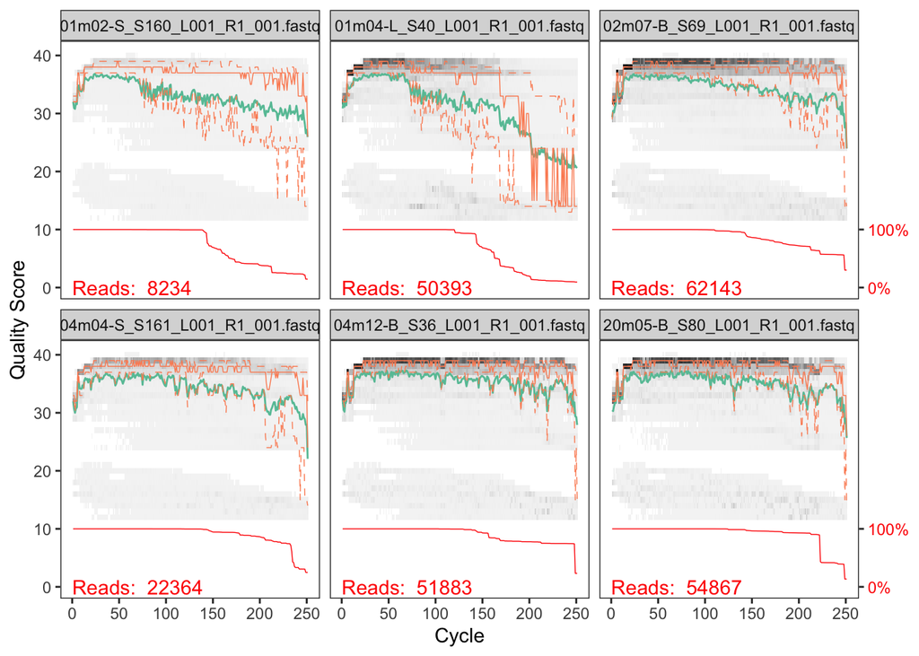

```r
#Inspect read quality profiles for forward reads
plotQualityProfile(cutFs[c(6,12,36,62,84,120)])
```

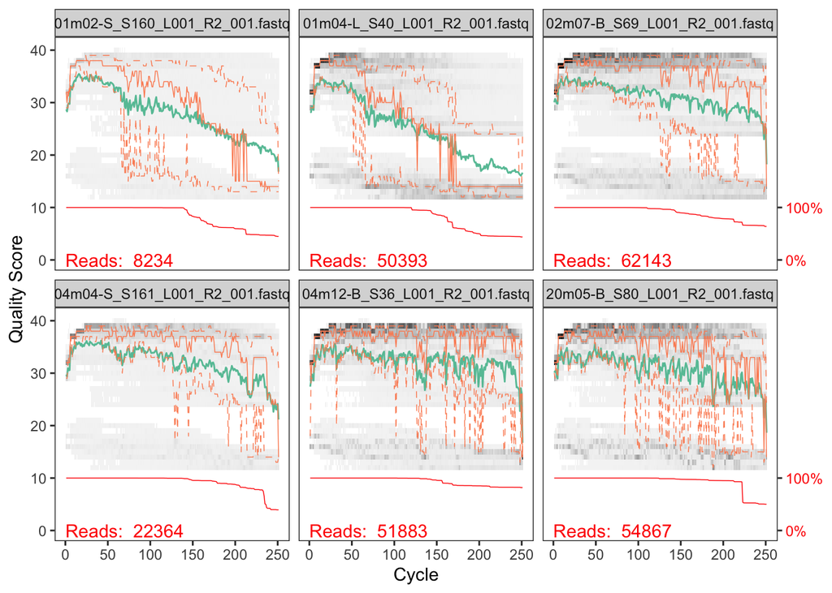

```r
#Inspect read quality profiles for reverse reads
plotQualityProfile(cutRs[c(6,12,36,62,84,120)])
```

Setting file paths for the samples we’re about to trim:

```r
#Filter and Trim
filtFs <- file.path(path.cut, "filtered", basename(cutFs))
filtRs <- file.path(path.cut, "filtered", basename(cutRs))

names(filtFs) <- sample.names
names(filtRs) <- sample.names
```

```r
##Trim trim trim!!
#Filter reads where both sets maintain a quality score ~30+ (error rate 1 in 1,000)
## Mac can multi-threat this, windows cannot ##
out <- filterAndTrim(cutFs, filtFs, cutRs, filtRs,
                     #truncLen=c(220,120),minLen=50,
                     maxN=0, maxEE=c(2,3), truncQ=2, rm.phix=TRUE,
                     compress=TRUE, multithread=TRUE)
out
```

```
##                                reads.in reads.out
## 01m01-B_S34_L001_R1_001.fastq     43975     35155
## 01m01-L_S4_L001_R1_001.fastq      46129     21641
## 01m01-S_S148_L001_R1_001.fastq    27321     17639
## 01m02-B_S46_L001_R1_001.fastq     76462     48015
## 01m02-L_S16_L001_R1_001.fastq     76187     49960
## 01m02-S_S160_L001_R1_001.fastq     8234      5196
## 01m03-B_S58_L001_R1_001.fastq     60429     47185
## 01m03-L_S28_L001_R1_001.fastq     83613     43967
## 01m03-S_S172_L001_R1_001.fastq    45097     30592
## 01m03-W_S142_L001_R1_001.fastq     5784      4212
## 01m04-B_S70_L001_R1_001.fastq     35636     26533
## 01m04-L_S40_L001_R1_001.fastq     50393     25707
## 01m04-S_S184_L001_R1_001.fastq    37777     26690
## 01m05-B_S82_L001_R1_001.fastq     59978     42177
## 01m05-L_S52_L001_R1_001.fastq     86716     44488
## 01m05-S_S101_L001_R1_001.fastq    25576     17428
## 01m06-B_S94_L001_R1_001.fastq     24238     16770
## 01m06-L_S64_L001_R1_001.fastq     74432     43527
## 01m06-S_S113_L001_R1_001.fastq    38987     24338
## 02m01-B_S92_L001_R1_001.fastq     34548     29051
## 02m01-L_S74_L001_R1_001.fastq     76393     42366
## 02m01-S_S111_L001_R1_001.fastq    40790     31940
## 02m02-B_S9_L001_R1_001.fastq      43955     31931
## 02m02-L_S86_L001_R1_001.fastq     48777     24853
## 02m02-S_S123_L001_R1_001.fastq    35672     26983
## 02m03-B_S21_L001_R1_001.fastq     76013     45518
## 02m03-L_S3_L001_R1_001.fastq      51031     33325
## 02m03-S_S135_L001_R1_001.fastq    64523     49053
## 02m04-L_S15_L001_R1_001.fastq     63636     44504
## 02m04-S_S147_L001_R1_001.fastq    22136     15866
## 02m05-B_S45_L001_R1_001.fastq     56844     44683
## 02m05-L_S27_L001_R1_001.fastq     98563     65773
## 02m06-B_S57_L001_R1_001.fastq     75874     50930
## 02m06-L_S39_L001_R1_001.fastq     76059     55956
## 02m06-S_S171_L001_R1_001.fastq    55988     38555
## 02m07-B_S69_L001_R1_001.fastq     62143     45774
## 02m07-L_S51_L001_R1_001.fastq    118246     76496
## 02m07-S_S183_L001_R1_001.fastq    75934     54335
## 02m08-B_S81_L001_R1_001.fastq     40275     33122
```

[output cut: 95 more lines]

```
## sfm05-B_S109_L001_R1_001.fastq    62392     48030
## sfm05-L_S90_L001_R1_001.fastq     81246     35565
## sfm05-S_S139_L001_R1_001.fastq    37735     27047
## sfm06-B_S121_L001_R1_001.fastq    25301     19708
## sfm06-L_S7_L001_R1_001.fastq      37064     25171
## sfm06-S_S151_L001_R1_001.fastq    36389     22485
## sfm07-B_S133_L001_R1_001.fastq    71696     52955
## sfm07-L_S19_L001_R1_001.fastq     57542     34494
## sfm07-S_S163_L001_R1_001.fastq    37167     24037
## Sft01-B_S31_L001_R1_001.fastq     74753     51304
## Sft01-L_S13_L001_R1_001.fastq     62788     40703
## Sft01-S_S145_L001_R1_001.fastq    47648     30106
## Sft02-B_S43_L001_R1_001.fastq     82307     66158
## Sft02-L_S25_L001_R1_001.fastq    100297     63591
## Sft02-S_S157_L001_R1_001.fastq    32398     21410
```

Now to inspect our filtered sequences:

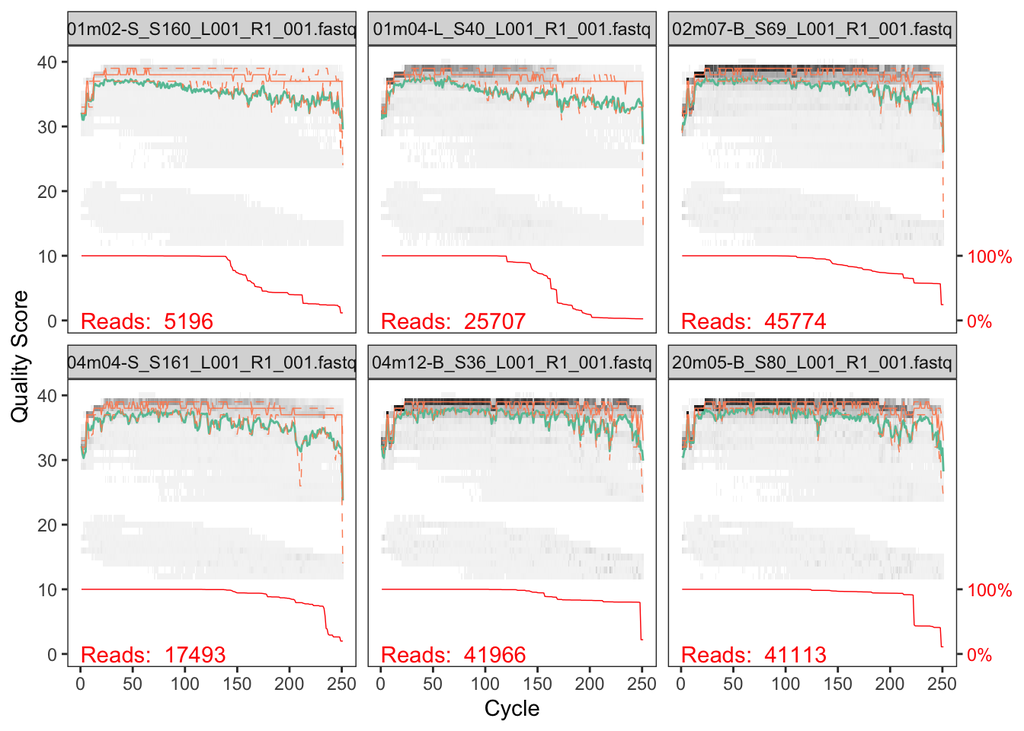

```r
#Re-inspect read quality profiles
plotQualityProfile(filtFs[c(6,12,36,62,84,120)])
```

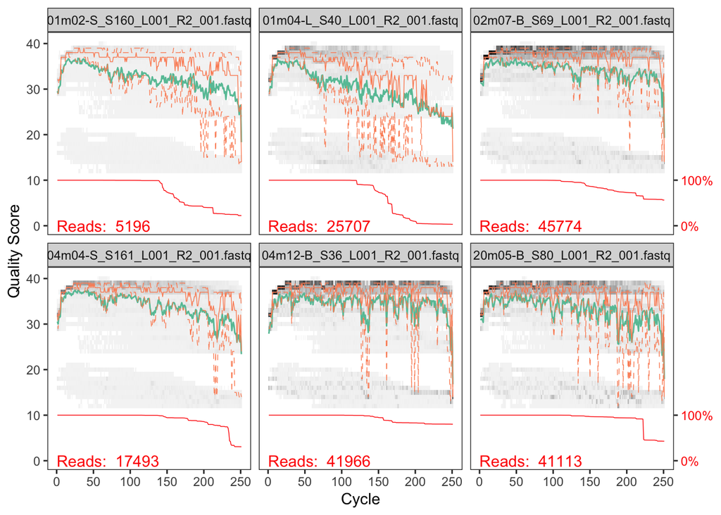

```r
#Re-inspect read quality profiles
plotQualityProfile(filtRs[c(6,12,36,62,84,120)])
```

Now to track down errors and remove them.

## Generate an Error Model

Buckle up, Chuck, this here **Machine Learning Algorithm** `learnErrors` will generate a parametric error model for the filtered sequence data. Dune.

```r
#Learn error rates
#!!~30 min each!!
errF <- learnErrors(filtFs, multithread=TRUE)
```

```
## 100430093 total bases in 503355 reads from 17 samples will be used for learning the error rates.
```

```r
#Learn error rates
#!!~30 min each!!
errR <- learnErrors(filtRs, multithread=TRUE)
```

```
## 100896686 total bases in 503355 reads from 17 samples will be used for learning the error rates.
```

Plotting errors

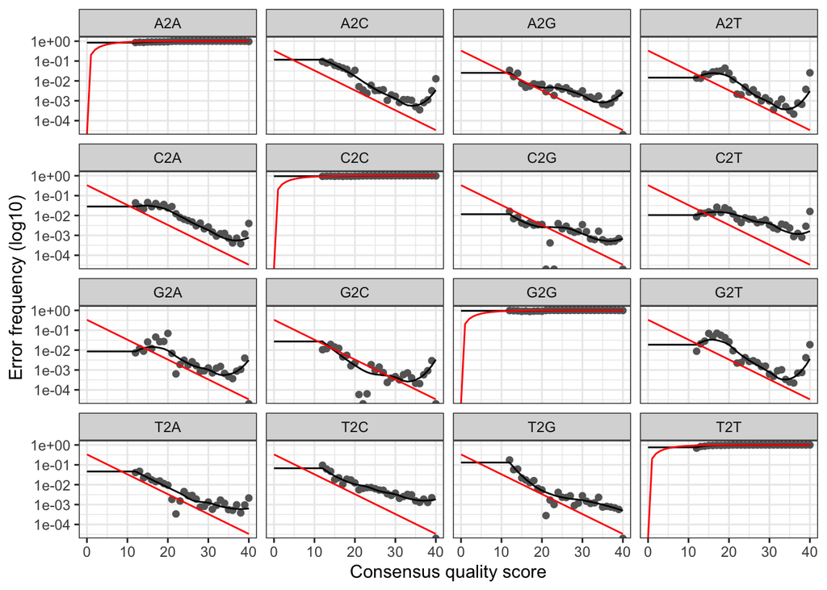

```r
#plot error forward
plotErrors(errF, nominalQ=TRUE)
```

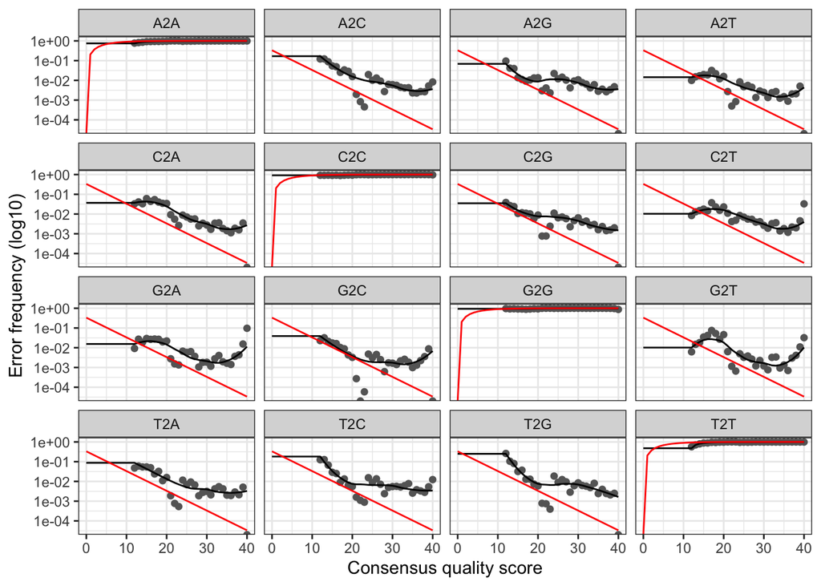

```r
#plot error reverse
plotErrors(errR, nominalQ=TRUE)
```

#Dereplication Dereplications means the computer only needs to analyse each identical sequence once, lumping anlyses and saving brain cells.

```r
#Dereplication
derep_forward <- derepFastq(filtFs, verbose=TRUE)
derep_reverse <- derepFastq(filtRs, verbose=TRUE)
names(derep_forward) <- sample.names
names(derep_reverse) <- sample.names
```

##Infer ASVs

```r
#Inferring ASVs
#Pool or pseudopool if particularly interested in rare taxa (e.g. singletons)

dadaFs <- dada(derep_forward, err=errF, pool="pseudo", multithread=TRUE)
```

```
## Sample 1 - 35155 reads in 7599 unique sequences.
## Sample 2 - 21641 reads in 5481 unique sequences.
## Sample 3 - 17639 reads in 5387 unique sequences.
## Sample 4 - 48015 reads in 11413 unique sequences.
## Sample 5 - 49960 reads in 10715 unique sequences.
## Sample 6 - 5196 reads in 1594 unique sequences.
## Sample 7 - 47185 reads in 10913 unique sequences.
## Sample 8 - 43967 reads in 7861 unique sequences.
## Sample 9 - 30592 reads in 8917 unique sequences.
## Sample 10 - 4212 reads in 939 unique sequences.
## Sample 11 - 26533 reads in 5865 unique sequences.
## Sample 12 - 25707 reads in 5671 unique sequences.
## Sample 13 - 26690 reads in 7788 unique sequences.
## Sample 14 - 42177 reads in 9790 unique sequences.
## Sample 15 - 44488 reads in 10074 unique sequences.
## Sample 16 - 17428 reads in 5966 unique sequences.
## Sample 17 - 16770 reads in 4587 unique sequences.
## Sample 18 - 43527 reads in 7969 unique sequences.
## Sample 19 - 24338 reads in 7825 unique sequences.
## Sample 20 - 29051 reads in 6106 unique sequences.
## Sample 21 - 42366 reads in 9959 unique sequences.
## Sample 22 - 31940 reads in 7605 unique sequences.
## Sample 23 - 31931 reads in 7066 unique sequences.
## Sample 24 - 24853 reads in 6108 unique sequences.
## Sample 25 - 26983 reads in 7225 unique sequences.
## Sample 26 - 45518 reads in 9536 unique sequences.
## Sample 27 - 33325 reads in 7030 unique sequences.
## Sample 28 - 49053 reads in 12983 unique sequences.
## Sample 29 - 44504 reads in 10216 unique sequences.
## Sample 30 - 15866 reads in 4942 unique sequences.
## Sample 31 - 44683 reads in 10600 unique sequences.
## Sample 32 - 65773 reads in 16371 unique sequences.
## Sample 33 - 50930 reads in 13615 unique sequences.
## Sample 34 - 55956 reads in 12619 unique sequences.
## Sample 35 - 38555 reads in 11302 unique sequences.
## Sample 36 - 45774 reads in 13015 unique sequences.
## Sample 37 - 76496 reads in 13285 unique sequences.
## Sample 38 - 54335 reads in 14752 unique sequences.
## Sample 39 - 33122 reads in 5396 unique sequences.
## Sample 40 - 51111 reads in 11328 unique sequences.
```

[output cut: 96 more lines]

```
## Sample 137 - 27047 reads in 7354 unique sequences.
## Sample 138 - 19708 reads in 4737 unique sequences.
## Sample 139 - 25171 reads in 7147 unique sequences.
## Sample 140 - 22485 reads in 8064 unique sequences.
## Sample 141 - 52955 reads in 16457 unique sequences.
## Sample 142 - 34494 reads in 9953 unique sequences.
## Sample 143 - 24037 reads in 8138 unique sequences.
## Sample 144 - 51304 reads in 14735 unique sequences.
## Sample 145 - 40703 reads in 9651 unique sequences.
## Sample 146 - 30106 reads in 11318 unique sequences.
## Sample 147 - 66158 reads in 14299 unique sequences.
## Sample 148 - 63591 reads in 14108 unique sequences.
## Sample 149 - 21410 reads in 6913 unique sequences.
##
##    selfConsist step 2
```

```r
dadaRs <- dada(derep_reverse, err=errR, pool="pseudo", multithread=TRUE)
```

```
## Sample 1 - 35155 reads in 11437 unique sequences.
## Sample 2 - 21641 reads in 12686 unique sequences.
## Sample 3 - 17639 reads in 9308 unique sequences.
## Sample 4 - 48015 reads in 20405 unique sequences.
## Sample 5 - 49960 reads in 20340 unique sequences.
## Sample 6 - 5196 reads in 2601 unique sequences.
## Sample 7 - 47185 reads in 16310 unique sequences.
## Sample 8 - 43967 reads in 19406 unique sequences.
## Sample 9 - 30592 reads in 15757 unique sequences.
## Sample 10 - 4212 reads in 1256 unique sequences.
## Sample 11 - 26533 reads in 8925 unique sequences.
## Sample 12 - 25707 reads in 13050 unique sequences.
## Sample 13 - 26690 reads in 12716 unique sequences.
## Sample 14 - 42177 reads in 19209 unique sequences.
## Sample 15 - 44488 reads in 21799 unique sequences.
## Sample 16 - 17428 reads in 9171 unique sequences.
## Sample 17 - 16770 reads in 6970 unique sequences.
## Sample 18 - 43527 reads in 19214 unique sequences.
## Sample 19 - 24338 reads in 12255 unique sequences.
## Sample 20 - 29051 reads in 8740 unique sequences.
## Sample 21 - 42366 reads in 22893 unique sequences.
## Sample 22 - 31940 reads in 11598 unique sequences.
## Sample 23 - 31931 reads in 11927 unique sequences.
## Sample 24 - 24853 reads in 10001 unique sequences.
## Sample 25 - 26983 reads in 10302 unique sequences.
## Sample 26 - 45518 reads in 20988 unique sequences.
## Sample 27 - 33325 reads in 15302 unique sequences.
## Sample 28 - 49053 reads in 18010 unique sequences.
## Sample 29 - 44504 reads in 19442 unique sequences.
## Sample 30 - 15866 reads in 7613 unique sequences.
## Sample 31 - 44683 reads in 17108 unique sequences.
## Sample 32 - 65773 reads in 27050 unique sequences.
## Sample 33 - 50930 reads in 21911 unique sequences.
## Sample 34 - 55956 reads in 21036 unique sequences.
## Sample 35 - 38555 reads in 18003 unique sequences.
## Sample 36 - 45774 reads in 19748 unique sequences.
## Sample 37 - 76496 reads in 33556 unique sequences.
## Sample 38 - 54335 reads in 23710 unique sequences.
## Sample 39 - 33122 reads in 12574 unique sequences.
## Sample 40 - 51111 reads in 25272 unique sequences.
```

[output cut: 96 more lines]

```
## Sample 137 - 27047 reads in 12144 unique sequences.
## Sample 138 - 19708 reads in 6603 unique sequences.
## Sample 139 - 25171 reads in 11877 unique sequences.
## Sample 140 - 22485 reads in 12389 unique sequences.
## Sample 141 - 52955 reads in 22474 unique sequences.
## Sample 142 - 34494 reads in 16175 unique sequences.
## Sample 143 - 24037 reads in 11831 unique sequences.
## Sample 144 - 51304 reads in 23154 unique sequences.
## Sample 145 - 40703 reads in 19175 unique sequences.
## Sample 146 - 30106 reads in 17560 unique sequences.
## Sample 147 - 66158 reads in 20897 unique sequences.
## Sample 148 - 63591 reads in 25860 unique sequences.
## Sample 149 - 21410 reads in 10885 unique sequences.
##
##    selfConsist step 2
```

```r
dadaFs[[1]]
```

```
## dada-class: object describing DADA2 denoising results
## 427 sequence variants were inferred from 7599 input unique sequences.
## Key parameters: OMEGA_A = 1e-40, OMEGA_C = 1e-40, BAND_SIZE = 16
```

NOW WE WILL MERGE #MERGE F and R

```r
#Merge forward and reverse reads (make contigs)

mergers <- mergePairs(dadaFs, derep_forward, dadaRs, derep_reverse,
                      #trimOverhang=TRUE, minOverlap=45,
                      verbose=TRUE)
## Note: new ITS DADA2 tutorial using our primers does not suggest trimming overhang or using a minOverlap greater than default of 12. This should result in retaining more reads, and we'll rely on chimera detection to detect spurious mergers. ...
```

Now construct a count table for our newly merged ASVs.

##Construct a Count Table

```r
#Construct ASV table
seqtab <- makeSequenceTable(mergers)
dim(seqtab)
```

```
## [1]   149 14219
```

Project1216R: 149 samples, 14219 putative ASVs…

```r
table(nchar(getSequences(seqtab)))
```

```
##
##  47  48  50  52  53  55  57  60  63  65  66  67  68  69  70  71  72  73  74  75
##   1   1   1   2   1   1   1   1   3   6   2   3   5   1   3   1   5   8   6  13
##  76  77  78  79  80  81  82  83  84  85  86  87  88  89  90  91  92  93  94  95
##   8  12  12  12  15  12  20  14   5  17  14  12   5   8   5  12  12  12   6   9
##  96  97  98  99 100 101 102 103 104 105 106 107 108 109 110 111 112 113 114 115
##  10  13  17  16  24  39  26  28  39  28  21  42  37  26  44  61  34  76  45  32
## 116 117 118 119 120 121 122 123 124 125 126 127 128 129 130 131 132 133 134 135
##  29  39  40  34  24  26  23  42  40  42  42  47  42  27  27  30  36  42  31  41
## 136 137 138 139 140 141 142 143 144 145 146 147 148 149 150 151 152 153 154 155
##  36  55  98  64  80  88  98 136 116  88 110 101 145 164 116  96  73  80  95  88
## 156 157 158 159 160 161 162 163 164 165 166 167 168 169 170 171 172 173 174 175
## 140  97  93 156  99  94 134 121 136 102 149 132 130  90 135 121  91 120 109 173
## 176 177 178 179 180 181 182 183 184 185 186 187 188 189 190 191 192 193 194 195
## 128 115 111 112  89 104 108  85  82 134 116 107  79 107 103  75 154  90 117 107
```

[output cut: 28 more lines]

```r
seqtab <- seqtab[,nchar(colnames(seqtab)) %in% 74:430]
table(nchar(getSequences(seqtab)))
```

```
##
##  74  75  76  77  78  79  80  81  82  83  84  85  86  87  88  89  90  91  92  93
##   6  13   8  12  12  12  15  12  20  14   5  17  14  12   5   8   5  12  12  12
##  94  95  96  97  98  99 100 101 102 103 104 105 106 107 108 109 110 111 112 113
##   6   9  10  13  17  16  24  39  26  28  39  28  21  42  37  26  44  61  34  76
## 114 115 116 117 118 119 120 121 122 123 124 125 126 127 128 129 130 131 132 133
##  45  32  29  39  40  34  24  26  23  42  40  42  42  47  42  27  27  30  36  42
## 134 135 136 137 138 139 140 141 142 143 144 145 146 147 148 149 150 151 152 153
##  31  41  36  55  98  64  80  88  98 136 116  88 110 101 145 164 116  96  73  80
## 154 155 156 157 158 159 160 161 162 163 164 165 166 167 168 169 170 171 172 173
##  95  88 140  97  93 156  99  94 134 121 136 102 149 132 130  90 135 121  91 120
## 174 175 176 177 178 179 180 181 182 183 184 185 186 187 188 189 190 191 192 193
## 109 173 128 115 111 112  89 104 108  85  82 134 116 107  79 107 103  75 154  90
## 194 195 196 197 198 199 200 201 202 203 204 205 206 207 208 209 210 211 212 213
## 117 107 135 106 119 120  96  95  92 101 107  75  53  77  71  65  50  40  72  44
```

[output cut: 22 more lines]

```r
dim(seqtab)
```

```
## [1]   149 13980
```

#### review

13980 ASVs, 149 samples.

Now to remove chimeras:

##Remove Chimeras

```r
#Remove chimeras
seqtab.nochim <- removeBimeraDenovo(seqtab, method="consensus", multithread=TRUE, verbose=TRUE)
```

```
## Identified 124 bimeras out of 13980 input sequences.
```

```r
## Identified 83 bimeras out of 2858 input sequences.
(sum(seqtab.nochim)/sum(seqtab))
```

```
## [1] 0.9962187
```

```r
(1-(sum(seqtab.nochim)/sum(seqtab)))
```

```
## [1] 0.003781343
```

```r
###OLD
#Identified 35 bimeras out of 7907 input sequences.
#[1] 0.9979256
#[1] 0.002074373


### NEW
#Identified 106 bimeras out of 13589 input sequences.
#[1] 0.9961605
#[1] 0.003839465

### 1216R March...
#Identified 94 bimeras out of 13270 input sequences.
#[1] 0.9962695
#[1] 0.003730497

### 1216R April
#Identified 96 bimeras out of 13660 input sequences.
#[1] 0.9962817
#[1] 0.003718295

##Identified 124 bimeras out of 13980 input sequences.
#[1] 0.9962187
#[1] 0.003781343
```

## Track Number of Reads Retained Through Pipeline

```r
#Count reads dropped through each step in the pipeline
getN <- function(x) sum(getUniques(x))
track <- data.frame(row.names=sample.names, dada2_input=out[,1],
                    filtered=out[,2], dada_f=sapply(dadaFs, getN),
                    dada_r=sapply(dadaRs, getN), merged=sapply(mergers, getN),
                    nonchim=rowSums(seqtab.nochim),
                    final_perc_reads_retained=round(rowSums(seqtab.nochim)/out[,1]*100, 1))
#View(track)
mean(track[,7])
```

```
## [1] 56.22013
```

```r
min(track[,7])
```

```
## [1] 14.3
```

```r
### change file name with new run-throughs!!
write.csv(track, "/Users/kuehnlab/Publishing/AIMS_KonzaSyn_ITS/dada2_final_read_tracking09-15-2023.csv")
```

## Classify ASV Taxonomy

We are using a combination of taxonomy assignment functions to provide alternatives to the handful of spurious classification provided by the otherwise accurate naive Bayesian approach of the dada2 assignTaxonomy() function. Using the ensembleTex package, we’ll merge the outputs

Using current UNITE general release for all eukaryotes: 9.0 2022-10-16 All eukaryotes 17 683 308 588 Current https://doi.org/10.15156/BIO/2483914 When using this resource, please cite it as follows: Abarenkov, Kessy; Zirk, Allan; Piirmann, Timo; Pöhönen, Raivo; Ivanov, Filipp; Nilsson, R. Henrik; Kõljalg, Urmas (2022): UNITE general FASTA release for eukaryotes 2. Version 16.10.2022. UNITE Community. https://doi.org/10.15156/BIO/2483914

Includes global and 3% distance singletons.

overnight!!!

```r
###
#Set Working Directory
setwd('/Users/kuehnlab/Publishing/AIMS_KonzaSyn_ITS')
#Classify ASVs
#!!~20 min each!!
tax_info <- assignTaxonomy(seqtab.nochim, "sh_general_release_dynamic_s_all_29.11.2022.fasta",
                           multithread=TRUE, tryRC=TRUE)
```

```
## UNITE fungal taxonomic reference detected.
```

```r
taxa.print <- tax_info
rownames(taxa.print) <- NULL
head(taxa.print)
```

```
##      Kingdom           Phylum             Class
## [1,] NA                NA                 NA
## [2,] "k__Fungi"        "p__Ascomycota"    "c__Dothideomycetes"
## [3,] "k__Stramenopila" "p__Ochrophyta"    "c__Bacillariophyceae"
## [4,] NA                NA                 NA
## [5,] "k__Fungi"        "p__Ascomycota"    "c__Dothideomycetes"
## [6,] "k__Fungi"        "p__Basidiomycota" "c__Agaricomycetes"
##      Order             Family               Genus
## [1,] NA                NA                   NA
## [2,] "o__Pleosporales" "f__Pleosporaceae"   "g__Alternaria"
## [3,] "o__Naviculales"  "f__Naviculaceae"    "g__Navicula"
## [4,] NA                NA                   NA
## [5,] "o__Capnodiales"  "f__Cladosporiaceae" "g__Cladosporium"
## [6,] "o__Phallales"    "f__Phallaceae"      "g__Phallus"
##      Species
## [1,] NA
## [2,] "s__tenuissima"
## [3,] "s__trivialis"
## [4,] NA
## [5,] "s__cladosporioides"
## [6,] "s__hadriani"
```

```r
#Generate FASTA file
asv_seqs <- colnames(seqtab.nochim)
asv_headers <- vector(dim(seqtab.nochim)[2], mode="character")
for (i in 1:dim(seqtab.nochim)[2]) {
  asv_headers[i] <- paste(">ASV", i, sep="_")
}
asv_fasta <- c(rbind(asv_headers, asv_seqs))
write(asv_fasta, "dada2fasta09-15-2023.fasta")

#Generate ASV table (.count_table file)
asv_tab <- t(seqtab.nochim)
row.names(asv_tab) <- sub(">", "", asv_headers)
write.table(t(asv_tab), "practice09-15-2023.count_table", sep="\t", quote=F, col.names=NA)

#Generate taxonomy table
rownames(tax_info) <- gsub(pattern=">", replacement="", x=asv_headers)
write.csv(tax_info, "dada2_taxonomy09-15-2023.csv")


### Chunk 3

library("Biostrings")
library(dplyr)
library(stringr)
library(usethis)
library(DECIPHER); packageVersion("DECIPHER")
```

```
## [1] '2.26.0'
```

```r
## [1] '2.14.0'

# read our sample fastas into DECIPHER format
fas <- "dada2fasta09-15-2023.fasta"
idseqs <- readDNAStringSet(fas)


load("TrainingSet_UNITE_decipher_03.30.2023.RData") # CHANGE TO THE PATH OF YOUR TRAINING SET
ids <- IdTaxa(idseqs, trainingSet, strand="both", threshold=50, processors=NULL, verbose=FALSE) # use all processors

### The rank labels got messed up somehow, finding a workaround.....
 testtt<- sapply(ids,"[[",1)

 taxmatx<-stringi::stri_list2matrix(testtt, byrow=TRUE)

 ranks <- c("root","kingdom", "phylum", "class", "order", "family", "genus", "species")
colnames(taxmatx)<-ranks
taxid_df<- as.data.frame(taxmatx[1:nrow(as.data.frame(idseqs)),2:8])
row.names(taxid_df)<- names(idseqs)
head(taxid_df)
```

```
##                 kingdom           phylum                class
## ASV_1 unclassified_Root             <NA>                 <NA>
## ASV_2          k__Fungi    p__Ascomycota   c__Dothideomycetes
## ASV_3   k__Stramenopila    p__Ochrophyta c__Bacillariophyceae
## ASV_4 unclassified_Root             <NA>                 <NA>
## ASV_5          k__Fungi    p__Ascomycota   c__Dothideomycetes
## ASV_6          k__Fungi p__Basidiomycota    c__Agaricomycetes
##                                 order           family         genus
## ASV_1                            <NA>             <NA>          <NA>
## ASV_2                 o__Pleosporales f__Pleosporaceae g__Alternaria
## ASV_3                  o__Naviculales  f__Naviculaceae   g__Navicula
## ASV_4                            <NA>             <NA>          <NA>
## ASV_5 unclassified_c__Dothideomycetes             <NA>          <NA>
## ASV_6                    o__Phallales    f__Phallaceae    g__Phallus
##                          species
## ASV_1                       <NA>
## ASV_2 unclassified_g__Alternaria
## ASV_3      s__Navicula_trivialis
## ASV_4                       <NA>
## ASV_5                       <NA>
## ASV_6        s__Phallus_hadriani
```

```r
library(stringr)
library(dplyr)
#library(magrittr)

idtax_table_commonizing<- taxid_df
is.na(idtax_table_commonizing$kingdom) <- startsWith(idtax_table_commonizing$kingdom, "unclassified_")
is.na(idtax_table_commonizing$phylum) <- startsWith(idtax_table_commonizing$phylum, "unclassified_")
is.na(idtax_table_commonizing$class) <- startsWith(idtax_table_commonizing$class, "unclassified_")
is.na(idtax_table_commonizing$order) <- startsWith(idtax_table_commonizing$order, "unclassified_")
is.na(idtax_table_commonizing$family) <- startsWith(idtax_table_commonizing$family, "unclassified_")
is.na(idtax_table_commonizing$genus) <- startsWith(idtax_table_commonizing$genus, "unclassified_")
is.na(idtax_table_commonizing$species) <- startsWith(idtax_table_commonizing$species, "unclassified_")
is.na(idtax_table_commonizing$species) <- endsWith(idtax_table_commonizing$species, "_sp")

#DECIPHER idtaxa uses redundant labeling, putting "s__Genus_species" in the species rank. We want to remove the "Genus" from the middle of this string to make it interoperable with the Bayesian taxonomy from dada2.


idtax_table_commonizing$species<- str_replace(idtax_table_commonizing$species, pattern = "__\\w+\\_", replacement = "__")

#blessed be, it worked! Now save it for the love of all that is holy.

write.csv(idtax_table_commonizing, "idtax_tab_09-15-2023.csv")
```

##[Corals] not in Kansas anymore The Bayesian approach has misclassified some fungi and stramenopiles as Metazoa and Viridiplantae. For example: for ASV_1178 and ASV_1300 (note that ASV # may change upon re-running) Bayesian approach IDed as:

ASV_1178 k__Metazoa p__Cnidaria c__Anthozoa o__Zoantharia f__Zoanthidae g__Palythoa s__grandis ASV_1300 k__Metazoa p__Cnidaria c__Anthozoa o__Zoantharia f__Zoanthidae g__Palythoa s__grandis

But there are certainly no corals in Kansas. IDTAXA IDed as:

ASV_1178 k__Fungi p__Ascomycota c__Dothideomycetes o__Pleosporales f__Phaeosphaeriaceae g__Leptospora NA ASV_1300 k__Fungi p__Ascomycota c__Dothideomycetes o__Pleosporales f__Phaeosphaeriaceae g__Leptospora NA

The two approachs agree on most fungi and stramenopiles, but it is the bayesian approach that misclassifies a minority of fungal and stramenopile sequences as Metazoans and Viridiplantaeans.

For ASVs identified as Metazoa and Viridiplantae by Bayesian approach, substitute in the taxonomy generated by IDTAXA:

```r
cured_bayes_tax<- as.data.frame(tax_info)
colnames(idtax_table_commonizing)<-colnames(tax_info)

rows_to_replace<- cured_bayes_tax$Kingdom=='k__Metazoa' | cured_bayes_tax$Kingdom=='k__Viridiplantae'

idtemp<-idtax_table_commonizing

# Loop over the rows to perform replacement
for(i in which(rows_to_replace)) {
  cured_bayes_tax[i, ] <- idtemp[i, ]
}
```

```r
library(tibble)
taxidf <- tibble::as_data_frame(idtemp)
row.names(taxidf) <- row.names(idtemp)
taxidf <- tibble::rownames_to_column(idtemp, "ASV")

bayesdf <- tibble::as_data_frame(cured_bayes_tax)
row.names(bayesdf) <- row.names(cured_bayes_tax)
bayesdf <- tibble::rownames_to_column(cured_bayes_tax, "ASV")

library(tidyverse)
taxidf <- as.data.frame(taxidf)
bayesdf<- as.data.frame(bayesdf)


library(ensembleTax)

xx <- list(taxidf, bayesdf)
names(xx) <- c("idtax", "bayes")
eTax1 <- assign.ensembleTax(xx,
                     tablenames = names(xx),
                     ranknames = colnames(taxidf)[2:ncol(taxidf)],
                     weights=rep(1,length(xx)),
                   #  ranknames = c("kingdom","phylum","class","order","family","genus","species"),
                     tiebreakz = c("bayes"),
                     count.na=FALSE,
                     assign.threshold = 0
                     )
# show the 3 individuals again for easy viewing:
lapply(xx, FUN = head)
```

```
## $idtax
##     ASV         Kingdom           Phylum                Class           Order
## 1 ASV_1            <NA>             <NA>                 <NA>            <NA>
## 2 ASV_2        k__Fungi    p__Ascomycota   c__Dothideomycetes o__Pleosporales
## 3 ASV_3 k__Stramenopila    p__Ochrophyta c__Bacillariophyceae  o__Naviculales
## 4 ASV_4            <NA>             <NA>                 <NA>            <NA>
## 5 ASV_5        k__Fungi    p__Ascomycota   c__Dothideomycetes            <NA>
## 6 ASV_6        k__Fungi p__Basidiomycota    c__Agaricomycetes    o__Phallales
##             Family         Genus      Species
## 1             <NA>          <NA>         <NA>
## 2 f__Pleosporaceae g__Alternaria         <NA>
## 3  f__Naviculaceae   g__Navicula s__trivialis
## 4             <NA>          <NA>         <NA>
## 5             <NA>          <NA>         <NA>
## 6    f__Phallaceae    g__Phallus  s__hadriani
```

[output cut: 16 more lines]

```r
#Set Working Directory
setwd('/Users/kuehnlab/Publishing/AIMS_KonzaSyn_ITS')

head(eTax1)
```

```
##     ASV         Kingdom           Phylum                Class           Order
## 1 ASV_1            <NA>             <NA>                 <NA>            <NA>
## 2 ASV_2        k__Fungi    p__Ascomycota   c__Dothideomycetes o__Pleosporales
## 3 ASV_3 k__Stramenopila    p__Ochrophyta c__Bacillariophyceae  o__Naviculales
## 4 ASV_4            <NA>             <NA>                 <NA>            <NA>
## 5 ASV_5        k__Fungi    p__Ascomycota   c__Dothideomycetes  o__Capnodiales
## 6 ASV_6        k__Fungi p__Basidiomycota    c__Agaricomycetes    o__Phallales
##               Family           Genus            Species
## 1               <NA>            <NA>               <NA>
## 2   f__Pleosporaceae   g__Alternaria      s__tenuissima
## 3    f__Naviculaceae     g__Navicula       s__trivialis
## 4               <NA>            <NA>               <NA>
## 5 f__Cladosporiaceae g__Cladosporium s__cladosporioides
## 6      f__Phallaceae      g__Phallus        s__hadriani
```

```r
write.csv(eTax1, "ensembleTax_tab_kzsyn_09-15-2023.csv")
```

Now create a version of fungi-only taxonomy and another for all eukaryotes identified to the Kindgom-level or lower.

```r
row.names(eTax1)<-eTax1$ASV
eTax1<- eTax1[,2:8]

#Set Working Directory
setwd('/Users/kuehnlab/Publishing/AIMS_KonzaSyn_ITS')

fungitax<- filter(eTax1, Kingdom=='k__Fungi')

write.csv(fungitax, "final_fungi_tax_tab_kzsyn_09-15-2023.csv")

full_euktax<- filter(eTax1, !is.na(Kingdom))

write.csv(full_euktax, "final_eukaryote_tax_tab_kzsyn_09-15-2023.csv")
```

#THIS IS DONE. With the outputs generated, you can move on to data analysis, which I will conduct in a seperate .RMD file.